# ST661-Project-Ironman

Ben Butler, Rose Maria George, Lida Elsa Chacko, Sahil Singh

2022-12-06

# ST661-Project-Ironman

Ben Butler-18430024

2022-12-06

## Ironman 2019

### Introduction

- This data set looks at the 2019 Ironman World Championship Results which took place in Kona, Hawaii.
- The data is divided into multiple columns which shows each of the 2,434 participant’s individual times for swimming, cycling and running as well as their overall times and how they rank in comparison to the other competitors.
- The data was collected and compiled together by a UK triathalon training company known as Coach Cox.
- We will be examining multiple questions for this data including:  
  1.) Performance of Male Athletes vs. Performance of Female Athletes  
  2.) How Different Nationalities Fared  
  3.) Comparing the Multiple Divisions the participants were divided up into  
  4.) Having A Closer Look at the Times for Swimming, Cycling and Running.

**Author’s Statements**  
* I Ben Butler had primary responsibility for the material in the Gender Comparison Section.

- I Rose Maria George had primary responsibility for the section looking at the different countries involved.
- I Lida Elsa Chacko had primary responsibility for the material in the section involving how the athletes were divided up by division and what age category performed best.
- I Sahil Singh had primary responsibility for looking into how the best athletes performed in the various stages of the ironman, as well as having a deeper look into the transition times.

**Packages Used**  
The following packages were used in the project:

- Tidyverse
- Lubridate

**Variables in the Data**  
The following variables were recorded for each observation:

- BIB (Unique number given to every runner)
- Name (Athletes’ Name)
- Country (Country they represented)
- Gender (Whether they were Male or Female)
- Division (The age and gender bracket they were competing in)
- Swim (The time it took to complete the swimming stage)
- Bike (The time it took to complete the cycling stage)
- Run (The time it took to complete the running stage)
- Overall (The overall finishing time)
- Division.Rank (Where the athlete ranked in their respective division)
- Gender.Rank (Where the athlete ranked in their respective gender)
- Overall.Rank (Where the athlete ranked Overall)
- T1 (The time it took between finishing the swim and starting the cycling)
- T2 (The time it took between finishing the cycling and starting the run)

```r
library("lubridate")
library(tidyverse)
ironman <- read.csv("~/BB18430024-ST661/Project/2019 Ironman World Championship Results.csv")
glimpse(ironman) # To read in the data and look at the dataset
```

```
## Rows: 2,434
## Columns: 14
## $ BIB           <int> 4, 6, 5, 14, 11, 9, 7, 47, 2, 28, 34, 16, 12, 10, 21, 56…
## $ Name          <chr> "Frodeno, Jan", "O'donnell, Tim", "Kienle, Sebastian", "…
## $ Country       <chr> "DEU", "USA", "DEU", "USA", "AUS", "GBR", "NZL", "CHE", …
## $ Gender        <chr> "Male", "Male", "Male", "Male", "Male", "Male", "Male", …
## $ Division      <chr> "MPRO", "MPRO", "MPRO", "MPRO", "MPRO", "MPRO", "MPRO", …
## $ Swim          <chr> "00:47:31", "00:47:38", "00:52:17", "00:51:01", "00:52:2…
## $ Bike          <chr> "04:16:02", "04:18:11", "04:15:04", "04:24:01", "04:14:4…
## $ Run           <chr> "02:42:43", "02:49:45", "02:49:56", "02:43:08", "02:55:0…
## $ Overall       <chr> "07:51:13", "07:59:41", "08:02:04", "08:02:52", "08:06:4…
## $ Division.Rank <chr> "1", "2", "3", "4", "5", "6", "7", "8", "9", "10", "11",…
## $ Gender.Rank   <chr> "1", "2", "3", "4", "5", "6", "7", "8", "9", "10", "11",…
## $ Overall.Rank  <chr> "1", "2", "3", "4", "5", "6", "7", "8", "9", "10", "11",…
## $ T1            <chr> "00:01:58", "00:02:01", "00:02:12", "00:02:25", "00:02:0…
## $ T2            <chr> "00:02:59", "00:02:06", "00:02:35", "00:02:17", "00:02:2…
```

**Data Preperation**  
To analyse the times in R properly, the columns, ‘Swim’, ‘Bike’, ‘Run’ and ‘Overall’ had to be converted into numeric characters using the function called “StringToMinutes” which takes the format HH:MM:SS and converted it into minutes only.

```r
# Defining function to convert string to integer minutes
StringToMinutes <- function(s)
  unlist(
    lapply(
      str_split(s,":"),function(s)
        sum(as.numeric(s)*c(60,1,1/60))
    )
  )

# Apply function to all time columns and look at data again
ironman$Swim <- StringToMinutes(ironman$Swim)
ironman$Bike <- StringToMinutes(ironman$Bike)
ironman$Run <- StringToMinutes(ironman$Run)
ironman$Overall <- StringToMinutes(ironman$Overall)

glimpse(ironman) # Shows new dataset
```

```
## Rows: 2,434
## Columns: 14
## $ BIB           <int> 4, 6, 5, 14, 11, 9, 7, 47, 2, 28, 34, 16, 12, 10, 21, 56…
## $ Name          <chr> "Frodeno, Jan", "O'donnell, Tim", "Kienle, Sebastian", "…
## $ Country       <chr> "DEU", "USA", "DEU", "USA", "AUS", "GBR", "NZL", "CHE", …
## $ Gender        <chr> "Male", "Male", "Male", "Male", "Male", "Male", "Male", …
## $ Division      <chr> "MPRO", "MPRO", "MPRO", "MPRO", "MPRO", "MPRO", "MPRO", …
## $ Swim          <dbl> 47.51667, 47.63333, 52.28333, 51.01667, 52.41667, 52.466…
## $ Bike          <dbl> 256.0333, 258.1833, 255.0667, 264.0167, 254.7333, 256.30…
## $ Run           <dbl> 162.7167, 169.7500, 169.9333, 163.1333, 175.0500, 173.50…
## $ Overall       <dbl> 471.2167, 479.6833, 482.0667, 482.8667, 486.6833, 487.76…
## $ Division.Rank <chr> "1", "2", "3", "4", "5", "6", "7", "8", "9", "10", "11",…
## $ Gender.Rank   <chr> "1", "2", "3", "4", "5", "6", "7", "8", "9", "10", "11",…
## $ Overall.Rank  <chr> "1", "2", "3", "4", "5", "6", "7", "8", "9", "10", "11",…
## $ T1            <chr> "00:01:58", "00:02:01", "00:02:12", "00:02:25", "00:02:0…
## $ T2            <chr> "00:02:59", "00:02:06", "00:02:35", "00:02:17", "00:02:2…
```

### Performance of Male Athletes vs. Performance of Female Athletes

In this section we will be looking at how Male athletes performed against how Female athletes performed.

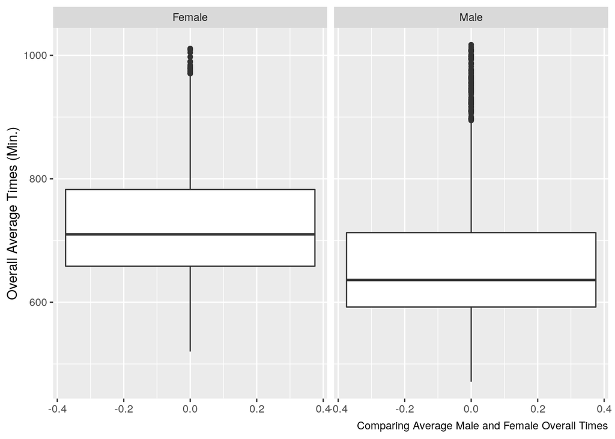

```r
ironman |>
  ggplot() +
  geom_boxplot(aes(y = Overall)) +
  facet_wrap(vars(Gender)) +
  labs(y = "Overall Average Times (Min.)", caption = "Comparing Average Male and Female Overall Times")
```

```r
# Boxplots to compare medain, outliers and quartiles of each gender
```

From the boxplots we can see that the males on average had a better overall time.

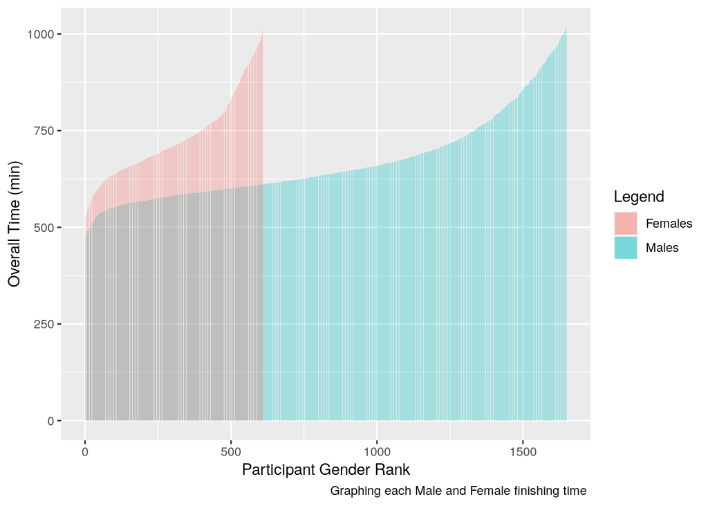

```r
# Separate the data into males and females
males <- ironman |>
            filter(Gender == "Male") |>
            select(-Gender, -Division, -Country,-Division.Rank)

females <- ironman |>
            filter(Gender == "Female") |>
            select(-Gender, -Division, -Country,-Division.Rank)

# Plot the Overall times for both genders on same plot
ggplot() +
  geom_bar(data = males, mapping = aes(x = 1:length(Overall), y = Overall,
                                       fill = "Males"),
           alpha = 0.3, stat = 'identity') +
  geom_bar(data = females, mapping = aes(x = 1:length(Overall), y=Overall,
                                         fill = "Females"),
           alpha = 0.3, stat = 'identity') +
  labs(x = "Participant Gender Rank", fill = "Legend",
       y = "Overall Time (min)",
       caption = "Graphing each Male and Female finishing time ")
```

This is shown again by the overlapping barplots. One thing to note however is that there were less female competitors overall than males.

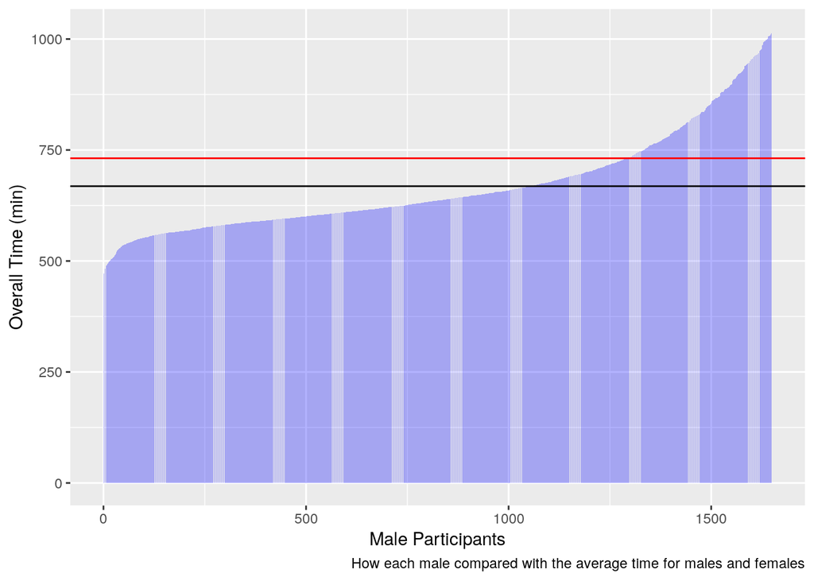

```r
# Analysing just the male participants
males |>
  ggplot() +
  geom_bar(mapping = aes(x = 1:length(Overall), y=Overall),
           alpha = 0.3, stat = 'identity', fill = 'blue') +
  geom_hline(yintercept =  mean(males$Overall, na.rm = TRUE)) +
  geom_hline(yintercept =  mean(females$Overall, na.rm = TRUE),
             colour = "red") + # Average line for females
  labs(x = "Male Participants", y = "Overall Time (min)", caption = "How each male compared with the average time for males and females")
```

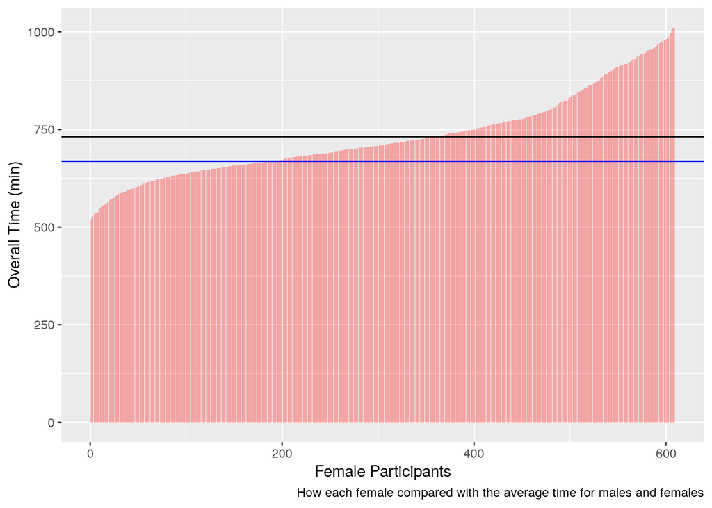

```r
# Analysing just the female participants
females |>
  ggplot() +
  geom_bar(mapping = aes(x = 1:length(Overall), y=Overall),
           alpha = 0.3, stat = 'identity', fill = 'red') +
  geom_hline(yintercept =  mean(females$Overall, na.rm = TRUE)) +
  geom_hline(yintercept =  mean(males$Overall, na.rm = TRUE),
             colour = "blue") + # Average line for males
  labs(x = "Female Participants", y = "Overall Time (min)", caption = "How each female compared with the average time for males and females")
```

```r
# Names of the fastest male and female athletes
print(paste("The fastest male overall is:",
            males$Name[which(males$Overall == min(males$Overall,
                                               na.rm = TRUE))]))
```

```
## [1] "The fastest male overall is: Frodeno, Jan"
```

```r
print(paste("The fastest female overall is:",
            females$Name[which(females$Overall == min(females$Overall,
                                               na.rm = TRUE))]))
```

```
## [1] "The fastest female overall is: Haug, Anne"
```

```r
# Getting the fastest, slowest and average male overall time
fastest_man <- min(males$Overall, na.rm = TRUE)
average_man <- mean(males$Overall, na.rm = TRUE)
slowest_man <- max(males$Overall, na.rm = TRUE)

# Getting the fastest, slowest and average female overall time
fastest_woman <- min(females$Overall, na.rm = TRUE)
average_woman <- mean(females$Overall, na.rm = TRUE)
slowest_woman <- max(females$Overall, na.rm = TRUE)

# Ratio comparing the fastest of each gender
Ratio_F_S <- abs(fastest_man-slowest_man)/abs(fastest_woman-slowest_woman)
Ratio_F_A <- abs(fastest_man-average_man)/abs(fastest_woman-average_woman)

# Table to put all the information together
RatioTable <- matrix(c(fastest_man, average_man, slowest_man,
                       abs(fastest_man-slowest_man),
                       abs(fastest_man-average_man),
                       Ratio_F_S, Ratio_F_A,
                       fastest_woman, average_woman, slowest_woman,
                       abs(fastest_woman-slowest_woman),
                       abs(fastest_woman-average_woman),
                       1/Ratio_F_S, 1/Ratio_F_A), ncol = 7, byrow = TRUE)

colnames(RatioTable) <- c('Fastest', 'Average', 'Slowest',
                          'Diff.Fast/Slow', 'Diff.Fast/Average',
                          'Ratio.Fast/Slow', 'Ratio.Fast/Average')

rownames(RatioTable) <- c('Males', 'Females')

RatioTable <- as.table(RatioTable)
RatioTable
```

```
##              Fastest      Average      Slowest Diff.Fast/Slow Diff.Fast/Average
## Males    471.2166667  668.5000101 1017.1500000    545.9333333       197.2833434
## Females  520.1666667  731.4008484 1011.0500000    490.8833333       211.2341817
##         Ratio.Fast/Slow Ratio.Fast/Average
## Males         1.1121448          0.9339556
## Females       0.8991635          1.0707147
```

From the table you can see that when comparing the 2 fastest athletes of both genders, Jan Frodeno and Anne Haug, Jan was 1.112 times faster than Anne when comparing both to the slowest competitor in each gender. However Anne was 1.071 times faster than Jan when comparing both to the average Overall times of their respective genders.  
Further analysis of the two genders will come later on…

### How Different Countries Fared

In this section we will examine which nationalities performed the best at the 2019 Ironman

```r
# Gets the Top 10 countries with the most competitors
top_10 <- ironman %>%
  group_by(Country) %>%
  summarise(participants = n()) %>%
    mutate(Percentage_of_Participants =
           participants/length(ironman$BIB)*100) %>%
  arrange(desc(participants))

head(top_10,10)
```

```
## # A tibble: 10 × 3
##    Country participants Percentage_of_Participants
##    <chr>          <int>                      <dbl>
##  1 USA              650                      26.7
##  2 DEU              277                      11.4
##  3 AUS              193                       7.93
##  4 GBR              162                       6.66
##  5 CAN               99                       4.07
##  6 FRA               95                       3.90
##  7 BRA               82                       3.37
##  8 JPN               72                       2.96
##  9 CHE               56                       2.30
## 10 ESP               56                       2.30
```

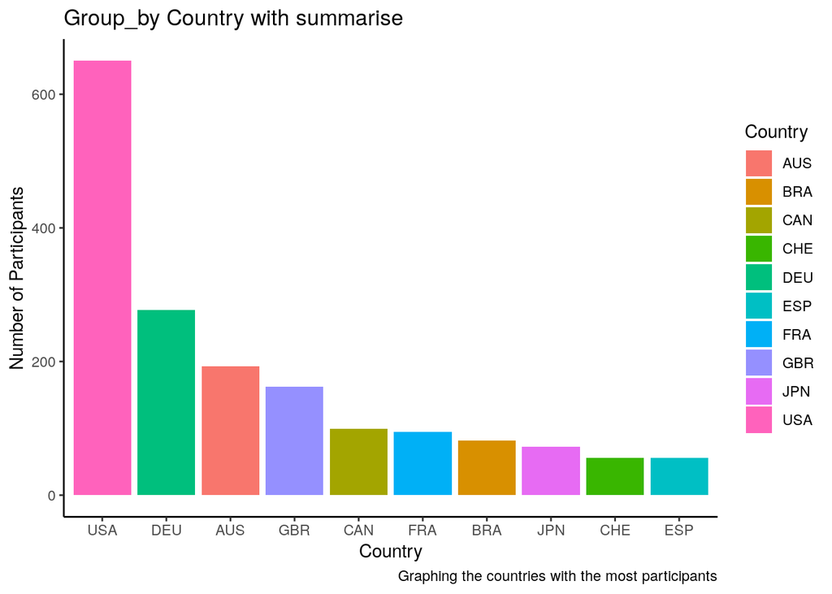

```r
# Visually shows the distance between USA and the rest of the Top10 in terms of participants
ggplot(head(top_10,10),aes(x = reorder(Country, -participants), y = participants, fill = Country)) +
  geom_bar(stat = "identity") +
  theme_classic() +
  labs(
    x = "Country",
    y = "Number of Participants",
    title = "Group_by Country with summarise",
    caption = "Graphing the countries with the most participants"
    )
```

From the table and barchart we can see that USA had the most participants in the 2019 ironman, with over 300 more racers than the next highest, Germany.  
Now let’s look at what country performed the best:

```r
# Arranging countries by Overall Time to see what country performed best
ironman |>
  group_by(Country) |>
  mutate(num_participants = n()) |>
  mutate(Overall.Average = mean(Overall, na.rm = TRUE)) |>
  arrange(Overall.Average) |>
  select(Country, Overall.Average, num_participants) |>
  distinct(Country, .keep_all = TRUE)
```

```
## # A tibble: 74 × 3
## # Groups:   Country [74]
##    Country Overall.Average num_participants
##    <chr>             <dbl>            <int>
##  1 PER                562.                1
##  2 ROU                566.                1
##  3 ISL                579.                1
##  4 LUX                586.                3
##  5 PRY                590.                2
##  6 IND                595.                1
##  7 TUR                605.                2
##  8 PRT                610.                5
##  9 NOR                616.               13
## 10 HUN                620.                6
## # … with 64 more rows
```

According to this table, Peru, Romania and Iceland performed the best, however they all only have one runner. For a fairer comparison let’s have the country require fifty or more runners:

```r
# Doing the same as above but putting a limit on amount of participants needed
ironman |>
  group_by(Country) |>
  mutate(num_participants = n()) |>
  mutate(Overall.Average = mean(Overall, na.rm = TRUE)) |>
  filter(num_participants >= 50) |>
  arrange(Overall.Average) |>
  select(Country, Overall.Average, num_participants) |>
  distinct(Country, .keep_all = TRUE)
```

```
## # A tibble: 12 × 3
## # Groups:   Country [12]
##    Country Overall.Average num_participants
##    <chr>             <dbl>            <int>
##  1 ESP                622.               56
##  2 BEL                632.               55
##  3 CHE                649.               56
##  4 BRA                654.               82
##  5 FRA                659.               95
##  6 DEU                659.              277
##  7 GBR                664.              162
##  8 SWE                666.               54
##  9 AUS                679.              193
## 10 CAN                704.               99
## 11 USA                733.              650
## 12 JPN                768.               72
```

This changes things a bit, now the table reads as Spain being the best performing country, with Belgium and Switzerland making the top three. Note how well Germany and Australia performed despite their mass number of participants.

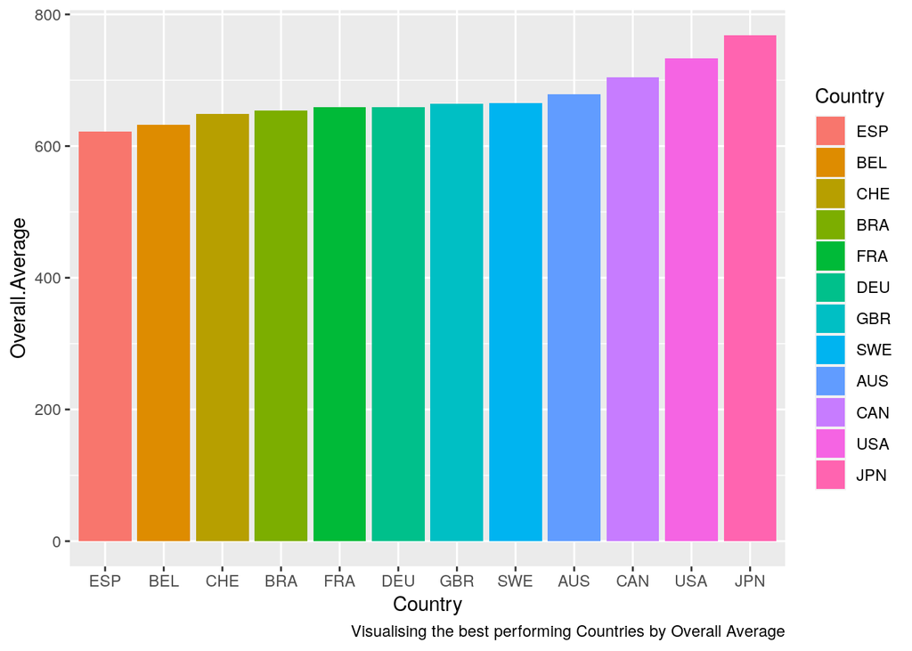

```r
# Graphing how well each country did
ironman |>
  group_by(Country) |>
  mutate(participants = n()) |>
  filter(participants >= 50) |>
  summarise(Overall.Average = mean(Overall, na.rm = TRUE)) |>
  arrange(Overall.Average) |>
  mutate(Country = fct_reorder(Country, Overall.Average, .desc = FALSE)) |>
  ggplot(aes(x = Country, y = Overall.Average,fill = Country)) +
  geom_bar(stat = "identity") +
  labs(caption = "Visualising the best performing Countries by Overall Average")
```

It is worth mentioning that while Spain may be the top performing country based on the average of everybody who finished the ironman, if we look at the nationalities of the Top10 athletes…

```r
# To look at top 10 athletes
ironman |>
  select(Name, Country, Overall) |>
  slice(1:10)
```

```
##                 Name Country  Overall
## 1       Frodeno, Jan     DEU 471.2167
## 2     O'donnell, Tim     USA 479.6833
## 3  Kienle, Sebastian     DEU 482.0667
## 4       Hoffman, Ben     USA 482.8667
## 5      Wurf, Cameron     AUS 486.6833
## 6       Skipper, Joe     GBR 487.7667
## 7     Currie, Braden     NZL 488.8000
## 8    Koutny, Philipp     CHE 490.4833
## 9     Aernouts, Bart     BEL 492.4500
## 10  Leiferman, Chris     USA 493.6167
```

… Germany have two in the top 10 and USA have three, with both of those countries having the two largest amounts of participants in this ironman, indicating that Germany and USA have a large range of overall finish times which takes the average down.

### Division/Age Comparison

There were multiple divisions in the dataset that divides the athletes up by gender, age and whether they are professional or not. Below we see how many athletes there was per division.

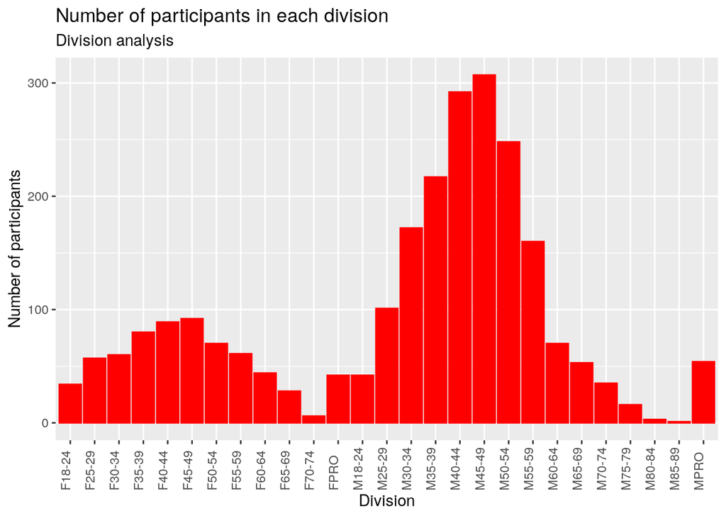

```r
# Graphing number of participants per division
ggplot(ironman, aes(x = Division)) +
  geom_bar(color="red", fill = "red") + theme(axis.text.x = element_text(angle = 90, vjust = 0, hjust=0)) +
  labs(title="Number of participants in each division",
       subtitle="Division analysis",

       x="Division",
       y="Number of participants")
```

However since the question about gender has already been discussed, in this section we will ignore segregation by gender and focus on their age and if they are a professional or not. First the data needs a new variable to represent what division they are in.

```r
# Adding new variable to data to seperate runners into age only
ironman <- ironman |>
  mutate(Age = case_when(
    Division == "MPRO" | Division == "FPRO" ~ "PRO",
    Division == "M18-24" | Division == "F18-24" ~ "18-24",
    Division == "M25-29" | Division == "F25-29" ~ "25-29",
    Division == "M30-34" | Division == "F30-34" ~ "30-34",
    Division == "M35-39" | Division == "F35-39" ~ "35-39",
    Division == "M40-44" | Division == "F40-44" ~ "40-44",
    Division == "M45-49" | Division == "F45-49" ~ "45-49",
    Division == "M50-54" | Division == "F50-54" ~ "50-54",
    Division == "M55-59" | Division == "F55-59" ~ "55-59",
    Division == "M60-64" | Division == "F60-64" ~ "60-64",
    Division == "M65-69" | Division == "F65-69" ~ "65-69",
    Division == "M70-74" | Division == "F70-74" ~ "70-74",
    Division == "M75-79" | Division == "F75-79" ~ "75-79",
    Division == "M80-84" | Division == "F80-84" ~ "80-84",
    Division == "M85-89" | Division == "F85-89" ~ "85-89"

  )
)

# Showing new Age variable on a table and graphically
ironman |>
  group_by(Age) |>
  mutate(num_Age = n()) |>
  arrange(desc(num_Age)) |>
  select(Name, Age, num_Age) |>
  distinct(Age, .keep_all = TRUE)
```

```
## # A tibble: 15 × 3
## # Groups:   Age [15]
##    Name                     Age   num_Age
##    <chr>                    <chr>   <int>
##  1 Vinokurov, Alexandre     45-49     399
##  2 Sorensen, Carsten Demant 40-44     381
##  3 Philippe, Anthony        50-54     318
##  4 Marques, Sergio          35-39     297
##  5 Caceres lopez, Ivan      30-34     232
##  6 Sweet, Richard           55-59     221
##  7 Tomasz, Aaron            25-29     158
##  8 Fergusson, Kevin         60-64     114
##  9 Frodeno, Jan             PRO        96
## 10 Azevedo, Roberto         65-69      81
## 11 Palm-henriksen, Gustav   18-24      76
## 12 Hefti, Hermann           70-74      41
## 13 Magliulo, Gennaro        75-79      16
## 14 Hill, Warren             80-84       3
## 15 Inada, Hiromu            85-89       1
```

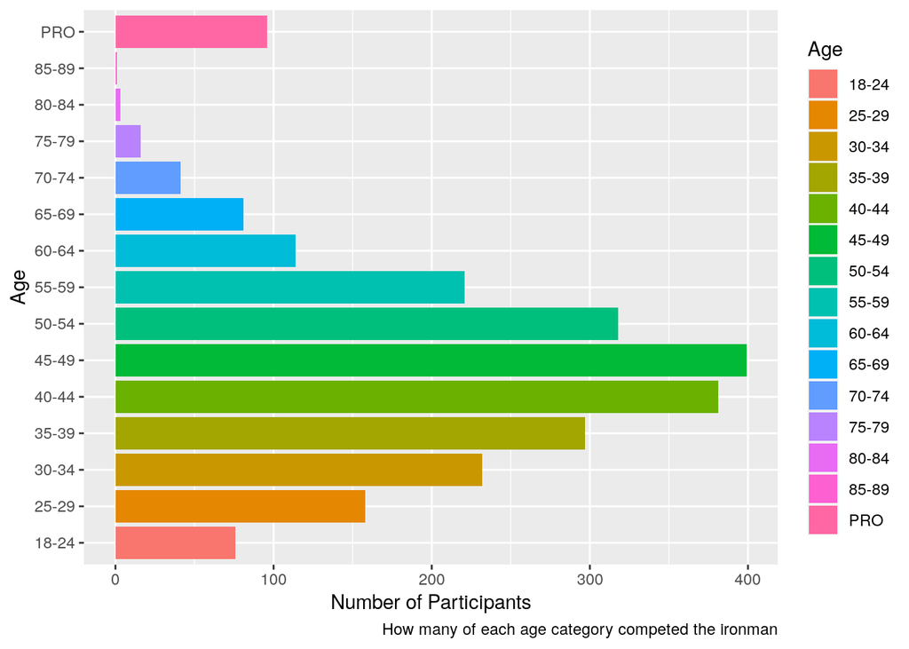

```r
ironman |>
  group_by(Age) |>
  mutate(num_Age = n()) |>
  arrange(desc(num_Age)) |>
  select(Name, Age, num_Age) |>
  distinct(Age, .keep_all = TRUE) |>
  ggplot(aes(x = num_Age, y = Age, fill = Age)) +
  geom_bar(stat = 'identity') +
  labs(x = "Number of Participants",
       caption = "How many of each age category competed the ironman")
```

From the graph above you can see that it was mostly 45-49 year olds that competed in the ironman, with just under 100 professionals taking part. Also those shown in the name category in the table above are the highest ranked athletes per age category.  
Now to see how well each age category performed based on their Overall Average:

```r
# Analysing which country performed best on average
ironman |>
  group_by(Age) |>
  summarise(Overall.AgeAv = mean(Overall, na.rm = TRUE)) |>
  arrange(Overall.AgeAv)
```

```
## # A tibble: 15 × 2
##    Age   Overall.AgeAv
##    <chr>         <dbl>
##  1 PRO            539.
##  2 30-34          621.
##  3 25-29          632.
##  4 35-39          638.
##  5 40-44          660.
##  6 45-49          680.
##  7 18-24          686.
##  8 50-54          714.
##  9 55-59          757.
## 10 60-64          789.
## 11 65-69          868.
## 12 75-79          881
## 13 70-74          929.
## 14 80-84          998.
## 15 85-89          NaN
```

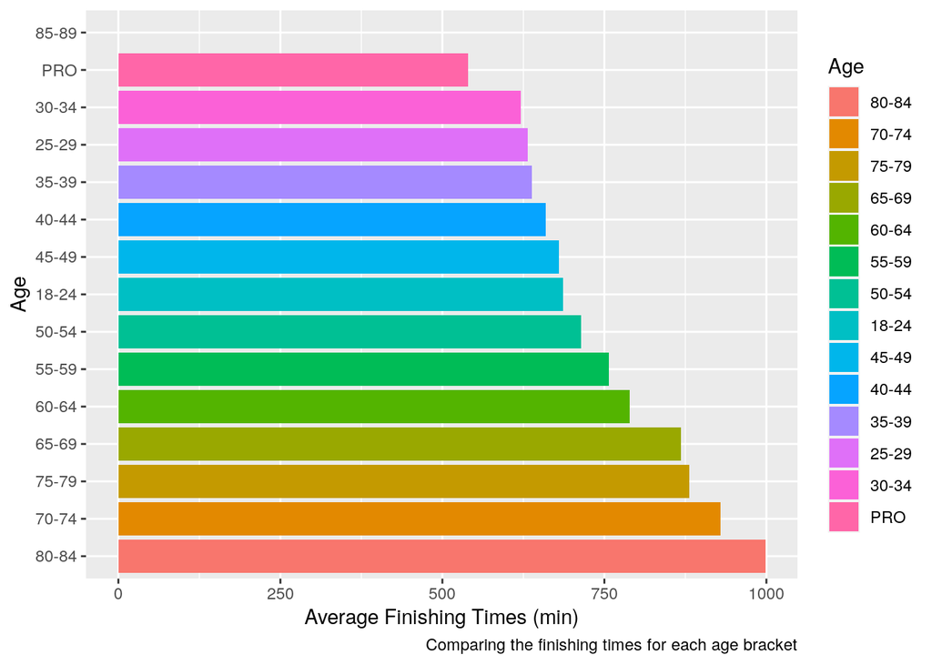

```r
ironman |>
  group_by(Age) |>
  summarise(Overall.AgeAv = mean(Overall, na.rm = TRUE)) |>
  arrange(Overall.AgeAv) |>
  mutate(Age = fct_reorder(Age, Overall.AgeAv, .desc = TRUE)) |>
  ggplot(aes(x = Overall.AgeAv, y = Age, fill = Age)) +
  geom_bar(stat = 'identity') +
  labs(x = "Average Finishing Times (min)",
       caption = "Comparing the finishing times for each age bracket")
```

As expected, the professionals had the lowest average time, with 30-34 year olds having the best average time for amateurs, while the older crowd were down near the bottom of the spectrum.  
However at the top of the graph we see 85-89 with zero minutes. This is because the one participant in that category sadly didn’t finish. This begs the question: was there a correlation between your age and whether or not you finished the race? To answer that we need a subset of the data of people with no Overall time.

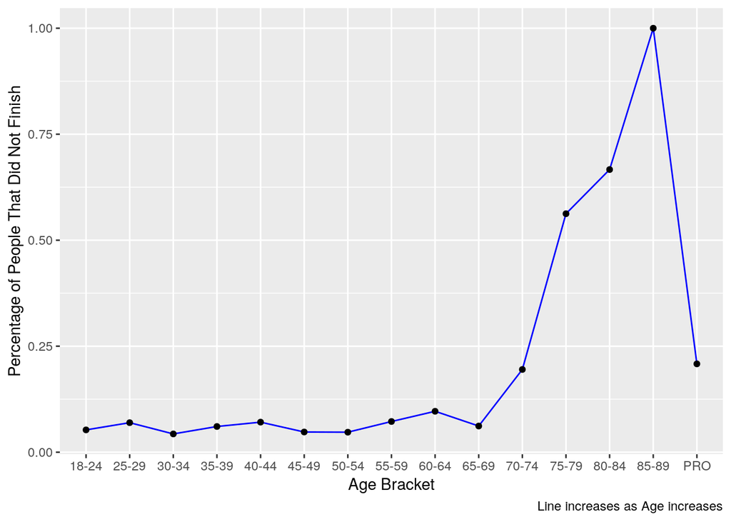

```r
# Seeing if there is a correlation between age and if you finished the race or not
ironman |>
  group_by(Age) |>
  mutate(total = n()) |>
  filter(is.na(Overall)) |>
  mutate(num = n()) |>
  mutate(ratio = num/total) |>
  distinct(Age, .keep_all = TRUE) |>
  select(Age, total, num, ratio) |>
  ggplot(aes(x = Age, y = ratio, group = 1)) +
  geom_line(color = 'blue') +
  geom_point() +
  labs(x = "Age Bracket", y = "Percentage of People That Did Not Finish",
       caption = "Line increases as Age increases")
```

From the graph there is an increase in the percentage of people that did not finish the race at 70+. 100% of people didn’t finish the race that were in the 85-89 bracket, although there was only one person who competed in that category. It is also interesting to note the high percentage of professionals that didn’t complete the race.

### Comparing Swim, Bike, and Run Times

The final question asked was how did the athletes compare for Swimming, Cycling and Running. Because it would be too difficult to compare them all, let’s take a subset of the Overall ten best athletes and compare how they ranked across the three stages of the ironman.

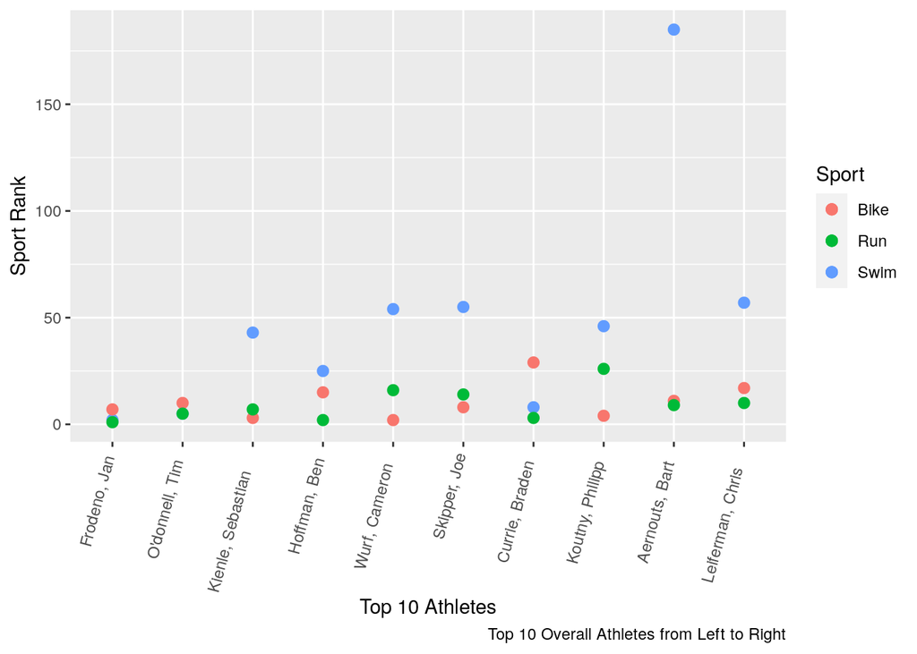

```r
# Ranking Top 10 athletes across all stages or ironman
ironman |>
  mutate(Swim.Rank = rank(Swim, ties.method = "first")) |>
  mutate(Bike.Rank = rank(Bike, ties.method = "first")) |>
  mutate(Run.Rank = rank(Run, ties.method = "first")) |>
  arrange(Overall) |>
  slice(1:10) |>
    ggplot() +
    geom_point(mapping = aes(x=factor(Name, levels = Name),
                             y = Swim.Rank,color='Swim'), size=2.5) +
    geom_point(mapping = aes(x=factor(Name, levels = Name),
                             y = Bike.Rank,color='Bike'), size=2.5) +
    geom_point(mapping = aes(x=factor(Name, levels = Name),
                             y = Run.Rank, color='Run'), size=2.5) +
    labs(x = "Top 10 Athletes", y = "Sport Rank", color = "Sport",
         caption = "Top 10 Overall Athletes from Left to Right") +
    theme(axis.text.x = element_text(angle = 75, vjust = 1.3, hjust = 1.5))
```

From the graph it is interesting to see how high the athletes outside of the top 2 fared in the Swimming leg of the ironman. Espcially the 9th place competitor, Bart Aernouts, how well he recovered from ranking over 185th in the Swim leg, to finish 9th overall.  
**Best Male and Female Times for all Stages** Comparing the Swim Stage:

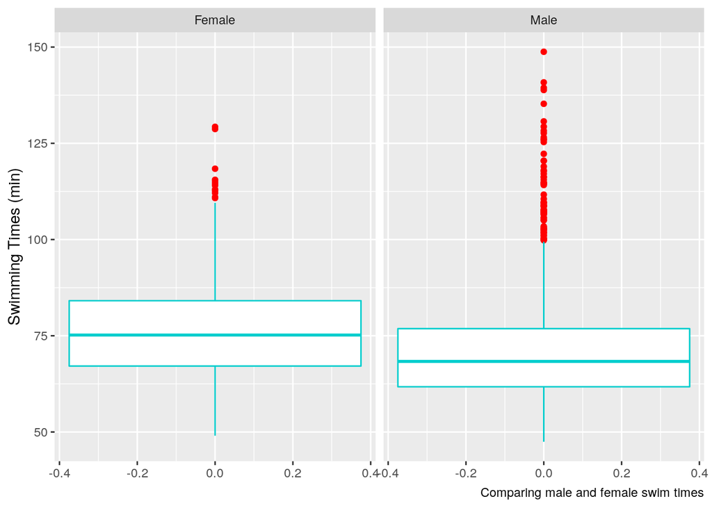

```r
ironman |>
  ggplot(aes(y = Swim )) +
  geom_boxplot(color="cyan3",outlier.color="red" ) +
  facet_wrap(vars(Gender)) +
  labs(y = "Swimming Times (min)",
       caption = "Comparing male and female swim times")
```

```r
print(paste("The fastest male swimmer is:",
            males$Name[which(males$Swim == min(males$Swim,
                                               na.rm = TRUE))]))
```

```
## [1] "The fastest male swimmer is: Amberger, Josh"
```

```r
print(paste("The fastest male swimmer is:",
            females$Name[which(females$Swim == min(females$Swim,
                                               na.rm = TRUE))]))
```

[output not shown]

Comparing the Cycling Stage:

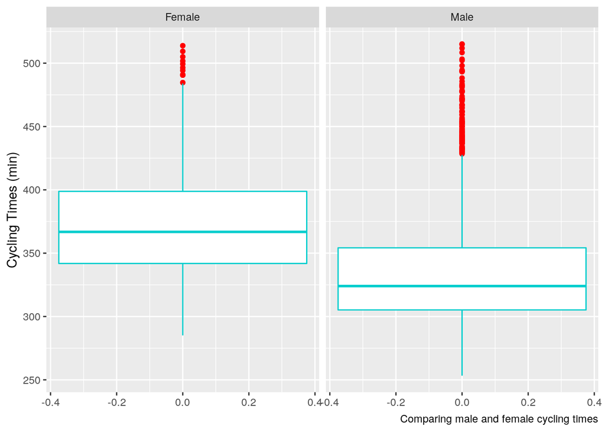

```r
ironman |>
  ggplot(aes(y = Bike )) +
  geom_boxplot(color="cyan3",outlier.color="red" ) +
  facet_wrap(vars(Gender)) +
  labs(y = "Cycling Times (min)",
       caption = "Comparing male and female cycling times")
```

```r
print(paste("The fastest male cyclist is:",
            males$Name[which(males$Bike == min(males$Bike,
                                               na.rm = TRUE))]))
```

```
## [1] "The fastest male cyclist is: Stein, Boris"
```

```r
print(paste("The fastest female cyclist is:",
            females$Name[which(females$Bike == min(females$Bike,
                                               na.rm = TRUE))]))
```

```
## [1] "The fastest female cyclist is: Philipp, Laura"
```

Comparing the Running Stage:

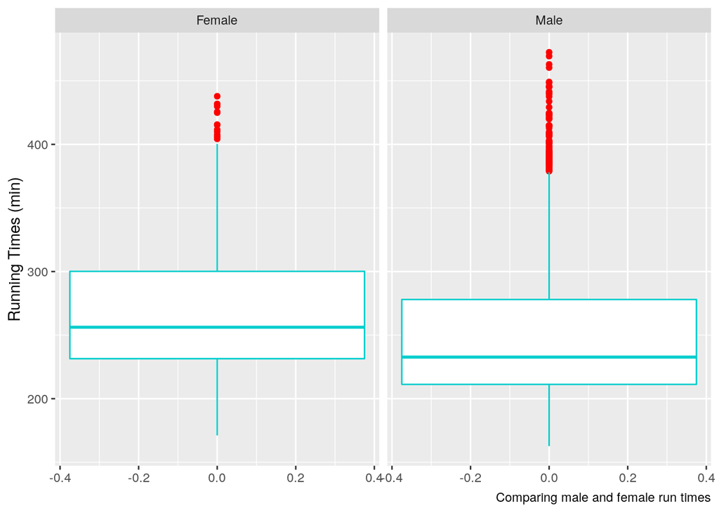

```r
ironman |>
  ggplot(aes(y = Run )) +
  geom_boxplot(color="cyan3",outlier.color="red" ) +
  facet_wrap(vars(Gender)) +
  labs(y = "Running Times (min)",
       caption = "Comparing male and female run times")
```

```r
print(paste("The fastest male runner is:",
            males$Name[which(males$Run == min(males$Run,
                                               na.rm = TRUE))]))
```

```
## [1] "The fastest male runner is: Frodeno, Jan"
```

```r
print(paste("The fastest male runner is:",
            females$Name[which(females$Run == min(females$Run,
                                               na.rm = TRUE))]))
```

[output not shown]

As expected (since the overall times for males was better), for each stage the men were faster. Let’s compare each stage to see which one had the closest time between males and females:

```r
print(paste("The difference in average swim times in minutes between men and women: ", abs(mean(males$Swim, na.rm = TRUE)-mean(females$Swim,
                                                    na.rm = TRUE))))
```

```
## [1] "The difference in average swim times in minutes between men and women:  5.70232726517357"
```

```r
print(paste("The difference in average cycling times in minutes between men and women: ", abs(mean(males$Bike, na.rm = TRUE)-mean(females$Bike,
                                                    na.rm = TRUE))))
```

```
## [1] "The difference in average cycling times in minutes between men and women:  37.4779467244161"
```

```r
print(paste("The difference in average swim times in minutes between men and women: ", abs(mean(males$Run, na.rm = TRUE)-mean(females$Run,
                                                    na.rm = TRUE))))
```

[output not shown]

As you can see, the shortest distance in times between men and women was in the Swimming event and the longest distance was in Cycling.  
**Transition Times** The athletes were also timed between their transition from the swim to the bike (T1) and from the bike to the run (T2). To analyse these times, a conversion into seconds makes the most sense as these times are small.

```r
my_time_hms1 <- hms(ironman$T1)
my_time_hms2 <- hms(ironman$T2)
```

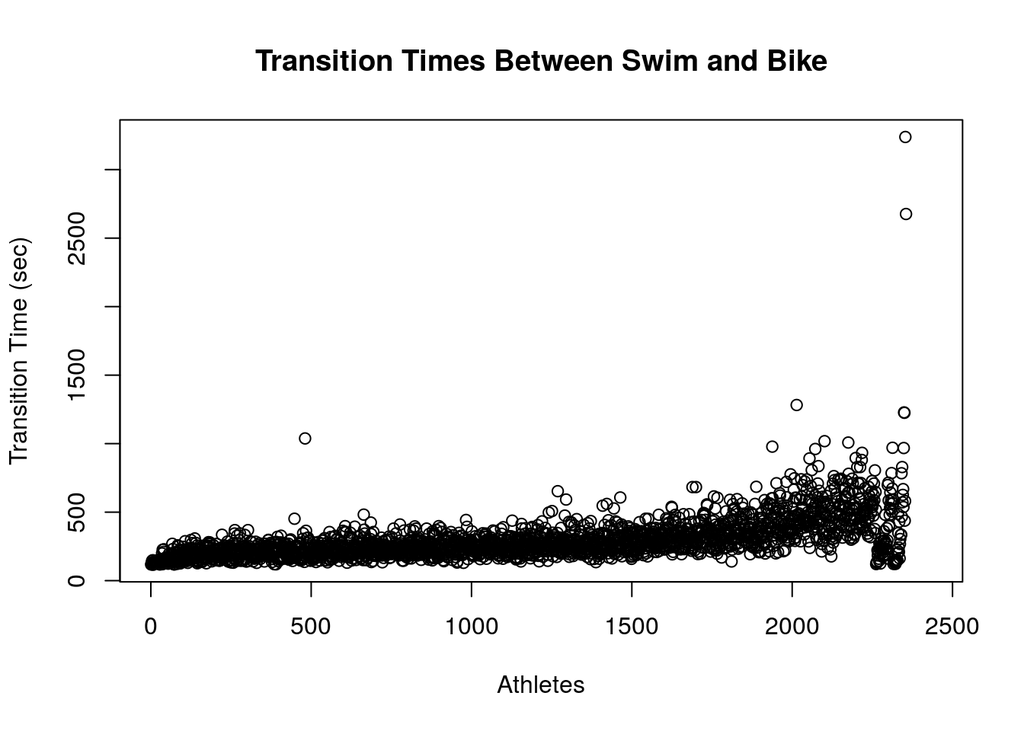

```r
T1_time_seconds <- period_to_seconds(my_time_hms1)
T2_time_seconds <- period_to_seconds(my_time_hms2)

plot(T1_time_seconds, xlab = "Athletes", ylab = "Transition Time (sec)",
     main = "Transition Times Between Swim and Bike")
```

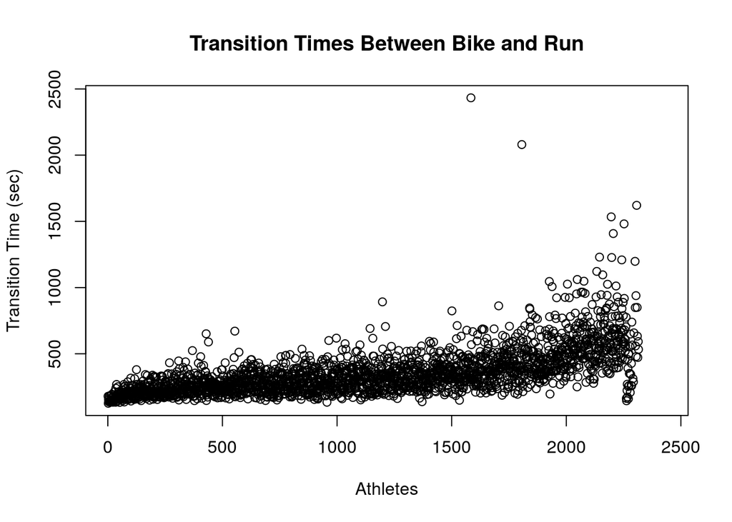

```r
plot(T2_time_seconds, xlab = "Athletes", ylab = "Transition Time (sec)",
     main = "Transition Times Between Bike and Run")
```

When comparing the two graphs above one thing to note is that the second transition time seemed to take longer for more athletes, possibly due to the fatigue that was starting to set in going into the final stage of the ironman. This is further proved when you look at the mean of the two transition times:

```r
print(paste("The average for T1 in seconds is:", mean(T1_time_seconds, na.rm = TRUE)))
```

```
## [1] "The average for T1 in seconds is: 297.88057798555"
```

```r
print(paste("The average for T2 in seconds is:", mean(T2_time_seconds, na.rm = TRUE)))
```

```
## [1] "The average for T2 in seconds is: 355.782854656223"
```